# Exercises

2024-04-16

## Functions

In these exercises we’re going to focus more on the application of functional programming in R with `functions()` and less on the nitty-gritty computer science stuff (theory). We’ll progressively build logic within these steps with the goal of making your code easy to use and efficient, which will hopefully help with not duplicating yourself all the time. The rule of thumb is 3. If you duplicate something more than 2 times you should probably write a function for it 😄.

### Exercise #1

In this exercise we’re going to start with a simple example: I want to know what the `mean` and `sd` are in a specific column of the `palmerpenguins` data.frame (or really any data.frame).

*Load the package and read-in the data.frame*

```r
#install.packages("palmerpenguins")
library(palmerpenguins)
data("penguins")

head(penguins)
```

```
## # A tibble: 6 × 8
##   species island    bill_length_mm bill_depth_mm flipper_length_mm body_mass_g
##   <fct>   <fct>              <dbl>         <dbl>             <int>       <int>
## 1 Adelie  Torgersen           39.1          18.7               181        3750
## 2 Adelie  Torgersen           39.5          17.4               186        3800
## 3 Adelie  Torgersen           40.3          18                 195        3250
## 4 Adelie  Torgersen           NA            NA                  NA          NA
## 5 Adelie  Torgersen           36.7          19.3               193        3450
## 6 Adelie  Torgersen           39.3          20.6               190        3650
## # ℹ 2 more variables: sex <fct>, year <int>
```

Lets get the `mean` in `bill_length_mm` column.

```r
mean(penguins$bill_length_mm, na.rm = TRUE) # na.rm = TRUE will calculate mean when there are NA's
```

```
## [1] 43.92193
```

Now what about `bill_depth_mm`.

```r
mean(penguins$bill_depth_mm, na.rm = TRUE)
```

```
## [1] 17.15117
```

But what about `sd`….

```r
sd(penguins$bill_length_mm, na.rm = TRUE)
```

```
## [1] 5.459584
```

You see how this will end up. We’ll just keep repeating ourselves for each column and each statistic…

This is were functions can really help. But how can we build a function? Let’s start simple:

1. What is a function?
2. We want `mean` and `sd` for specific columns.

#### What is a function?

A `function` in R has three main components to it: `formals()`, `body()`, and `environment()`.

*First we need to create an example function.*

This function takes a vector and some logical arguments that then calculates the mean of the vector two different ways, e.g. population and sample.

```r
my_mean <- function(vector, remove_na = TRUE, sample = TRUE) {

  if(sample){

    sum(vector, na.rm = remove_na)/(length(vector)-1)

  } else {

    sum(vector, na.rm = remove_na)/length(vector)

    }
}
```

*Break down function*

The `formals()` are going to be the arguments that you call within the `function()` call. This tells the `body()` what objects to look for first. Since R uses lexical scoping it will look for objects from the inside out, e.g. `environment()`. This can be manipulated but most of the time you won’t need to change this.

```r
formals(my_mean)
```

```
## $vector
##
##
## $remove_na
## [1] TRUE
##
## $sample
## [1] TRUE
```

```r
body(my_mean)
```

```
## {
##     if (sample) {
##         sum(vector, na.rm = remove_na)/(length(vector) - 1)
##     }
##     else {
##         sum(vector, na.rm = remove_na)/length(vector)
##     }
## }
```

```r
environment(my_mean)
```

```
## <environment: R_GlobalEnv>
```

#### Getting mean and sd

Reiterating, a function is a way to not duplicate code and is really handy for repetitive tasks. In the example below, we’ll start to build a function that will eventually be the `mean` and `sd` of a column in a `data.frame`.

```r
descriptive_stats_function <- function() {

  print('Getting mean and sd')

}

descriptive_stats_function()
```

```
## [1] "Getting mean and sd"
```

That’s easy enough, what about adding arguments? Arguments are ways to provide objects and/or statements to call within your function. For an argument, let’s provide the `pengiuns` data.frame and get the `length()` and `nrow()` of the data.frame and print that information out.

```r
descriptive_stats_function <- function(data) {

  cat(paste0('There are ', length(data), ' columns and ' , nrow(data), ' rows in this data.frame'))

}

descriptive_stats_function(penguins)
```

```
## There are 8 columns and 344 rows in this data.frame
```

**Practice**

*Try and build a function that takes a data.frame as an argument and column name as an argument and get back the mean and sd for those columns. Call it `descriptive_stats_function`*.

Hint: Indexing the data.frame/tibble by column name can help, e.g. `pengiuns[,c('bill_depth_mm')]`

### Exercise #2

In this exercise we’ll start adding some more flexibility to the function by adding extra arguments. In the previous exercise we created a function called `descriptive_stats_function()` but we hard coded in the `mean` and `sd`. What if we wanted the median? Or some other custom function? This is where we can add in an argument to help with multiple results.

*for-loop*

A lot of times you’ll here that a for-loop is really bad practice in R because of *copy when modified* behavior and that’s not a bad take, especially for large objects! But, if vectorized or using small object sizes it’s really not that bad and can help frame functions we’ll use later on. It also can help with repetitive tasks that really only need a few things changed. Below we’ll do a simple `for` loop to show how we might be able to accomplish exercise #2.

```r
penguin_col_names <- names(penguins)

penguin_col_names
```

```
## [1] "species"           "island"            "bill_length_mm"
## [4] "bill_depth_mm"     "flipper_length_mm" "body_mass_g"
## [7] "sex"               "year"
```

```r
for (i in penguin_col_names) {

  cat(paste0('Column ', match(i, penguin_col_names), ': ', i, '\n'))

}
```

```
## Column 1: species
## Column 2: island
## Column 3: bill_length_mm
## Column 4: bill_depth_mm
## Column 5: flipper_length_mm
## Column 6: body_mass_g
## Column 7: sex
## Column 8: year
```

What’s nice about this is we can put it within a function call.

```r
print_column_names <- function(data) {

  col_names <- names(penguins)

for (i in col_names) {

  cat(paste0('Column ', match(i, col_names), ': ', i, '\n'))

}


}

print_column_names(penguins)
```

```
## Column 1: species
## Column 2: island
## Column 3: bill_length_mm
## Column 4: bill_depth_mm
## Column 5: flipper_length_mm
## Column 6: body_mass_g
## Column 7: sex
## Column 8: year
```

```r
str(penguins)
```

```
## tibble [344 × 8] (S3: tbl_df/tbl/data.frame)
##  $ species          : Factor w/ 3 levels "Adelie","Chinstrap",..: 1 1 1 1 1 1 1 1 1 1 ...
##  $ island           : Factor w/ 3 levels "Biscoe","Dream",..: 3 3 3 3 3 3 3 3 3 3 ...
##  $ bill_length_mm   : num [1:344] 39.1 39.5 40.3 NA 36.7 39.3 38.9 39.2 34.1 42 ...
##  $ bill_depth_mm    : num [1:344] 18.7 17.4 18 NA 19.3 20.6 17.8 19.6 18.1 20.2 ...
##  $ flipper_length_mm: int [1:344] 181 186 195 NA 193 190 181 195 193 190 ...
##  $ body_mass_g      : int [1:344] 3750 3800 3250 NA 3450 3650 3625 4675 3475 4250 ...
##  $ sex              : Factor w/ 2 levels "female","male": 2 1 1 NA 1 2 1 2 NA NA ...
##  $ year             : int [1:344] 2007 2007 2007 2007 2007 2007 2007 2007 2007 2007 ...
```

Now if we want to store that information in a `vector` we just need to pre-allocate it. There are multiple ways to this but for this example we’ll store it in a `list()`. Also, since `cat()` is a `print()` side-effect we’ll need to capture the output using `capture.output()`.

```r
print_column_names <- function(data) {

  col_names <- names(penguins)

  # pre-allocate empty list

  my_col_names_list <- list()

for (i in col_names) {

  #now store in the list
  my_stored_list <- capture.output(cat(paste0('Column ', match(i, col_names), ': ', i, '\n')))

  # and append to my_col_names_list
  my_col_names_list <- append(my_col_names_list, my_stored_list)

}

  return(my_col_names_list)

}

for_loop_example <- print_column_names(penguins)

for_loop_example
```

```
## [[1]]
## [1] "Column 1: species"
##
## [[2]]
## [1] "Column 2: island"
##
## [[3]]
## [1] "Column 3: bill_length_mm"
##
## [[4]]
## [1] "Column 4: bill_depth_mm"
##
## [[5]]
## [1] "Column 5: flipper_length_mm"
##
## [[6]]
## [1] "Column 6: body_mass_g"
##
## [[7]]
## [1] "Column 7: sex"
##
## [[8]]
## [1] "Column 8: year"
```

**Practice**

*Now let’s take our function from before (exercise #1 `descriptive_stats_function()`) and add a new argument that will take a list of function names.*

We really want the user to be able to bring in any function right? How might we do this within a for-loop?

Hint: `?do.call` is a great base R function to help with this.

### Exercise #3

In this exercise we’ll go through potential issues with the function we created in exercise #2. Sometimes when building a function that *loops* it can cause errors where the conditions might not be satisfied. This happens a lot with API calls to some endpoint on the web but can also happen when your data is expecting one thing (`character`) and is given another (`numeric`).

[output not shown]

Instead of adding a function name that’s *quoted*, we’ll add a function type and see what happens.

```r
descriptive_stats_function(penguins, 'bill_length_mm', function_name = function(x) x/100)
```

```
## Error in for (i in function_name) {: invalid for() loop sequence
```

We get an expected error! How might we fix this? Well just like before, there are multiple ways to do this but a standard in base R is to use the `tryCatch()` function. Here is an example below:

```r
catching_error <- function(x) {

  x/100

}

catching_error(1)
```

```
## [1] 0.01
```

```r
catching_error(c(1:5))
```

```
## [1] 0.01 0.02 0.03 0.04 0.05
```

```r
# now with an error
catching_error('1')
```

```
## Error in x/100: non-numeric argument to binary operator
```

```r
catching_error <- function(x) {

  tryCatch(x/100, # expression to be evaluated
                             error = function(e) {
                               message('ERROR: converted non-numeric type to NA')
                               NA_real_
                               })

}

# now it prints a message
catching_error('1')
```

```
## [1] NA
```

This is great but it really is useful within a *loop*.

```r
catching_error <- function(x) {

  divide_by_100 <- vector()

  for(i in seq_along(x)){

  divide_by_100[[i]] <- tryCatch(x[[i]]/100, # expression to be evaluated
                                  error = function(e){
                                    message('ERROR: converted non-numeric type to NA')
                                    NA_real_
                                    } # what to return if error happens
                                 )

  }

  divide_by_100

}

catching_error(c(1, 2, 3, 4))
```

```
## [1] 0.01 0.02 0.03 0.04
```

```r
catching_error(c(1,10,100, '1', 10, 100)) # because R coercion rules converts all elements to string
```

```
## [1] NA NA NA NA NA NA
```

```r
catching_error(list(1,10,100, '1', 10, 100)) # so need a list
```

```
## [1] 0.01 0.10 1.00   NA 0.10 1.00
```

**Practice**

*Try to catch an error in `descriptive_stats_function()` when adding `function_name = function(x) x/100`*

Hint: the output within the for-loop will need to account for the non-character type.

## Mapping

In this section we’ll take what we learned from before and use those same concepts to `purrr::map` functions in R. These suite of functions are very similar to the `*apply` base R functions but offer some additional functionality to help with iterating over multiple objects. We’ll start by creating bootstrapped versions of the pengiuns dataset using `map()`. `map` is essentially a for-loop like we learned before but with more oversight and speed (written in C). This will help us not shoot ourselves in the foot creating our own for-loop functions.

### Exercise #4

Our goal is to create some bootstrapped versions of the pengiuns dataset but first let’s do some simple `map`-ing calls. If you are familiar with `for` loops then moving to `map()` functionality is really just replacing and matching what you would do in the `for` loop.

Let’s go back to our practice example in exercise #3 where we take a simple function like `function(x) x/100` and loop through a vector. This is a really verbose function and could use some refactoring to help with all the gotchas but what’s nice is it’s essentially setup for `map()`.

```r
library(purrr)

divide_by_100 <- function(x) x/100


map(1:5, # the vector/list to be used
    divide_by_100 ) # the function that will use vector/list
```

```
## [[1]]
## [1] 0.01
##
## [[2]]
## [1] 0.02
##
## [[3]]
## [1] 0.03
##
## [[4]]
## [1] 0.04
##
## [[5]]
## [1] 0.05
```

```r
map(list(1, '1', 10), divide_by_100)
```

```
## Error in `map()`:
## ℹ In index: 2.
## Caused by error in `x / 100`:
## ! non-numeric argument to binary operator
```

We still get that error… A way to control for this is a function called `safely`. This will return a list with `result` and `error` for each element. This is very similar to `tryCatch()` and will help with finicky or unknown data.

```r
map(list(1, '1', 10), safely(divide_by_100))
```

```
## [[1]]
## [[1]]$result
## [1] 0.01
##
## [[1]]$error
## NULL
##
##
## [[2]]
## [[2]]$result
## NULL
##
## [[2]]$error
## <simpleError in x/100: non-numeric argument to binary operator>
##
##
## [[3]]
## [[3]]$result
## [1] 0.1
##
## [[3]]$error
## NULL
```

Now all we need to do is clean up a little and we’ll have a similar function as before.

```r
map(list(1, '1', 10), safely(divide_by_100, otherwise = NA_real_)) |>
  map(~.x[['result']]) |>
  rbind() |>
  as.numeric()
```

```
## [1] 0.01   NA 0.10
```

```r
map(list(1, '1', 10), possibly(divide_by_100, otherwise = NA_real_)) |>
  rbind() |>
  as.numeric()
```

```
## [1] 0.01   NA 0.10
```

Another thing to be aware of is the syntax within the function call. Above we really weren’t explicitly passing the list or atomic vector to the function or weren’t writing out an anonymous function like `function(x) x/100`. However, sometimes you’ll want to think of it as explicitly passing this information, i.e. functions that are not anonymous or one argument. This is because `purrr` handles the `~` (called “twiddle”) as a way to translate the rhs into a function. For example,

```r
map(list(penguins, penguins), ~descriptive_stats_function(.x, cols = 'bill_length_mm', function_name = c('mean'), na.rm = TRUE))
```

```
## [[1]]
##                 mean
## function_output 43.92193
##
## [[2]]
##                 mean
## function_output 43.92193
```

```r
as_mapper(~descriptive_stats_function(.x, cols = 'bill_length_mm', function_name = c('mean'), na.rm = TRUE))
```

```
## <lambda>
## function (..., .x = ..1, .y = ..2, . = ..1)
## descriptive_stats_function(.x, cols = "bill_length_mm", function_name = c("mean"),
##     na.rm = TRUE)
## attr(,"class")
## [1] "rlang_lambda_function" "function"
```

Above you can see that this allows us to think of the arguments as . for one argument (..1) or .x for one argument and .y for the second argument (..2) and so forth. So when we use `map()` we’ll want to remember that we are just sending positions from the `list` or `vector` into the function.

**Practice**

Hint: you’ll want to put the penguins into 10 different lists.

### Exercise #5

Now that we have a bootstrapped dataset of 10 different samples, we’ll want to perform some summary stats with it. Just like before we can use this list of data.frames to call a function on. So now we want to see how different these datasets are, right? Let’s look at each of these data.frames and plot a linear model to them as well as the original dataset.

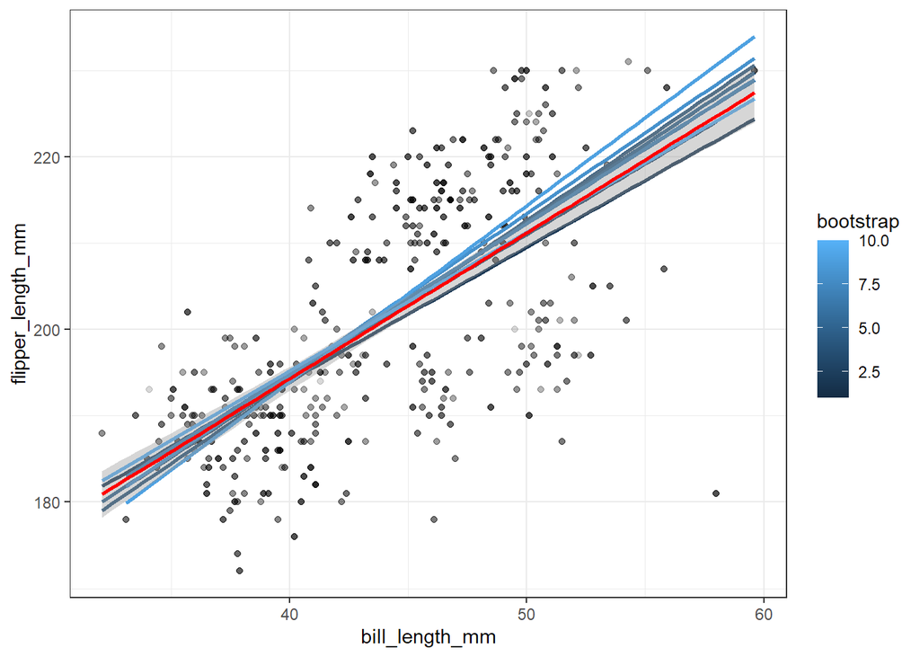

```r
library(ggplot2)

map2(penguins_rs, 1:10, ~.x |> mutate(bootstrap = .y)) |>
  bind_rows() |>
  ggplot(aes(bill_length_mm, flipper_length_mm)) +
  geom_point(alpha = 0.08) +
  geom_smooth(aes(group = bootstrap, color = bootstrap), method = 'lm', se = FALSE) +
  stat_smooth(data = penguins,geom = 'smooth', color = 'red',
              aes(bill_length_mm, flipper_length_mm),
              method = 'lm',
              se = TRUE) +
  theme_bw()
```

```r
summary(lm(flipper_length_mm ~ bill_length_mm, data = penguins))
```

```
##
## Call:
## lm(formula = flipper_length_mm ~ bill_length_mm, data = penguins)
##
## Residuals:
##     Min      1Q  Median      3Q     Max
## -43.708  -7.896   0.664   8.650  21.179
##
## Coefficients:
##                Estimate Std. Error t value Pr(>|t|)
## (Intercept)    126.6844     4.6651   27.16   <2e-16 ***
## bill_length_mm   1.6901     0.1054   16.03   <2e-16 ***
## ---
## Signif. codes:  0 '***' 0.001 '**' 0.01 '*' 0.05 '.' 0.1 ' ' 1
##
## Residual standard error: 10.63 on 340 degrees of freedom
##   (2 observations deleted due to missingness)
## Multiple R-squared:  0.4306, Adjusted R-squared:  0.4289
## F-statistic: 257.1 on 1 and 340 DF,  p-value: < 2.2e-16
```

We see that there is some sort of table but not like a normal data.frame so we need to save to an object to see what the elements are called.

```r
looking_at_summary <- summary(lm(flipper_length_mm ~ bill_length_mm, data = penguins))

str(looking_at_summary)
```

```
## List of 12
##  $ call         : language lm(formula = flipper_length_mm ~ bill_length_mm, data = penguins)
##  $ terms        :Classes 'terms', 'formula'  language flipper_length_mm ~ bill_length_mm
##   .. ..- attr(*, "variables")= language list(flipper_length_mm, bill_length_mm)
##   .. ..- attr(*, "factors")= int [1:2, 1] 0 1
##   .. .. ..- attr(*, "dimnames")=List of 2
##   .. .. .. ..$ : chr [1:2] "flipper_length_mm" "bill_length_mm"
##   .. .. .. ..$ : chr "bill_length_mm"
##   .. ..- attr(*, "term.labels")= chr "bill_length_mm"
##   .. ..- attr(*, "order")= int 1
##   .. ..- attr(*, "intercept")= int 1
##   .. ..- attr(*, "response")= int 1
##   .. ..- attr(*, ".Environment")=<environment: R_GlobalEnv>
##   .. ..- attr(*, "predvars")= language list(flipper_length_mm, bill_length_mm)
##   .. ..- attr(*, "dataClasses")= Named chr [1:2] "numeric" "numeric"
##   .. .. ..- attr(*, "names")= chr [1:2] "flipper_length_mm" "bill_length_mm"
##  $ residuals    : Named num [1:342] -11.766 -7.442 0.206 4.29 -3.104 ...
##   ..- attr(*, "names")= chr [1:342] "1" "2" "3" "5" ...
##  $ coefficients : num [1:2, 1:4] 126.684 1.69 4.665 0.105 27.156 ...
##   ..- attr(*, "dimnames")=List of 2
##   .. ..$ : chr [1:2] "(Intercept)" "bill_length_mm"
##   .. ..$ : chr [1:4] "Estimate" "Std. Error" "t value" "Pr(>|t|)"
##  $ aliased      : Named logi [1:2] FALSE FALSE
##   ..- attr(*, "names")= chr [1:2] "(Intercept)" "bill_length_mm"
##  $ sigma        : num 10.6
##  $ df           : int [1:3] 2 340 2
##  $ r.squared    : num 0.431
##  $ adj.r.squared: num 0.429
##  $ fstatistic   : Named num [1:3] 257 1 340
##   ..- attr(*, "names")= chr [1:3] "value" "numdf" "dendf"
##  $ cov.unscaled : num [1:2, 1:2] 1.93e-01 -4.32e-03 -4.32e-03 9.84e-05
##   ..- attr(*, "dimnames")=List of 2
##   .. ..$ : chr [1:2] "(Intercept)" "bill_length_mm"
##   .. ..$ : chr [1:2] "(Intercept)" "bill_length_mm"
##  $ na.action    : 'omit' Named int [1:2] 4 272
##   ..- attr(*, "names")= chr [1:2] "4" "272"
##  - attr(*, "class")= chr "summary.lm"
```

We can see that there is a `vector` called `$coefficients` so let’s pull that and check it out.

```r
looking_at_summary$coefficients
```

```
##                  Estimate Std. Error  t value     Pr(>|t|)
## (Intercept)    126.684427  4.6650807 27.15589 3.647979e-87
## bill_length_mm   1.690062  0.1054042 16.03410 1.743974e-43
```

Ok, this is good! Now we know we’ll need the first column and second row for the slope estimate.

```r
looking_at_summary$coefficients[2, 1]
```

```
## [1] 1.690062
```

**Practice**

*Use the steps above to `map()` through the `penguins_rs` and get the slopes of each linear model output. Call the object `penguins_coefs`.*

Hint: using `$` will help grab the needed coefficients.

### Exercise #6

For this final exercise we’ll want to see how far off the original dataset is with the bootstrapped data set. Using all the techniques up to this point we’ll want to create our own function and `map()` to the original dataset slope with the newly created bootstrap slopes. We are hoping to get an idea of the magnitude of difference between the slopes and then can visualise like below.

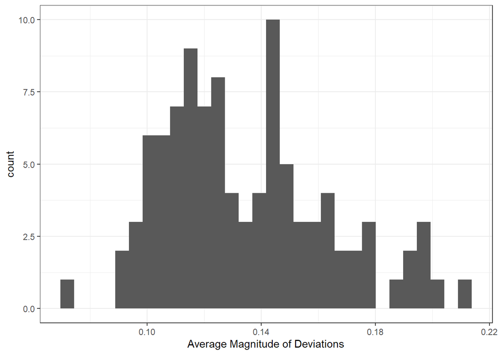

**Practice**

*Use the functional programming style of `purrr` to compare the original dataset slope and the bootstrapped ones by calculating the absolute difference.*

Hint: You’ll want to explore the `map2()` function.